# Технические вопросы работы с временными рядами

Заходякин Г.В., postlogist@gmail.com

# Введение

В этом блокноте рассмотрены различные технические вопросы работы с временными рядами в R:

- как получить временной ряд из табличных данных,
- как сохранить прогноз в файл,
- как получить временной ряд на основе транзакционных данных.

Настройка вывода:

```r
options(digits = 3) # Количество значащих цифр при выводе
```

Подключение пакетов:

```r
library(zoo) # работа с высокочастотными временными рядами, в этом блокноте используется только функция сохранения ряда в файл
library(tidyverse) # визуализация и трансформация данных
library(forecast) # анализ временных рядов и прогнозирование
library(lubridate) # работа с датами
```

# Как сделать временной ряд `ts`

В R есть несколько структур данных для хранения временных рядов. Пакет `forecast` может работать только с временными рядами класса `ts`. Поэтому, если вы хотите его использовать, потребуется преобразовать данные в этот формат.

В качестве примера возьмем временной ряд с ежемесячными продажами шампанского, полученный из репозитория [DataMarket](https://datamarket.com/data/set/22qf/monthly-champagne-sales-in-1000s-p273-montgomery-fore-ts)

```r
champ_tbl <- read_csv2('data/monthly_champagne_sales_in_1000s.csv', comment = '#')
head(champ_tbl)
```

```
## # A tibble: 6 x 2
##   Month `Champagne sales (in 1000's)`
##   <chr>                         <dbl>
## 1 1-01                           2851
## 2 1-02                           2672
## 3 1-03                           2755
## 4 1-04                           2721
## 5 1-05                           2946
## 6 1-06                           3036
```

**Примечание:** в файле первые несколько строк - комментарии, помеченные символом `#` в начале строки, поэтому в функции для считывания данных надо указать символ для комментария как аргумент.

Видим два столбца - текстовый, содержащий номер периода и числовой, с объемом продаж в тысячах единиц. Для удобства дальнейшей работы, поменяем имена столбцов на более короткие:

```r
names(champ_tbl) <- c('period', 'sales')
head(champ_tbl, 3)
```

```
## # A tibble: 3 x 2
##   period sales
##   <chr>  <dbl>
## 1 1-01    2851
## 2 1-02    2672
## 3 1-03    2755
```

Также видно, что в таблице данных нет дат, указаны лишь порядковый номер года в истории наблюдений и номер месяца, причем в одном текстовом столбце. Для удобства, разделим эти компоненты на отдельные столбцы с помощью функции `dplyr::separate()`:

```r
champ_tbl2 <- champ_tbl %>%
  separate(period, into = c('year', 'month'), sep = '-', convert = TRUE)

head(champ_tbl2)
```

```
## # A tibble: 6 x 3
##    year month sales
##   <int> <int> <dbl>
## 1     1     1  2851
## 2     1     2  2672
## 3     1     3  2755
## 4     1     4  2721
## 5     1     5  2946
## 6     1     6  3036
```

Временной ряд `ts` состоит из вектора наблюдений и индекса. В качестве индекса используется возрастающая последовательность чисел (обычно это годы). Если ряд содержит более частые наблюдения - например, ежемесячные или ежеквартальные, то необходимо задать **частоту** ряда (*frequency*), т.е. количество наблюдений в течение года.

В данном примере вместо года придется использовать порядковый номер. Частота равна 12, т.к. данные ежемесячные.

```r
champ <- ts(data = champ_tbl2$sales,
            start = first(champ_tbl2$year),
            frequency = 12)

champ
```

```
##     Jan   Feb   Mar   Apr   May   Jun   Jul   Aug   Sep   Oct   Nov   Dec
## 1  2851  2672  2755  2721  2946  3036  2282  2212  2922  4301  5764  7132
## 2  2541  2475  3031  3266  3776  3230  3028  1759  3595  4474  6838  8357
## 3  3113  3006  4047  3523  3937  3986  3260  1573  3528  5211  7614  9254
## 4  5375  3088  3718  4514  4520  4539  3663  1643  4739  5428  8314 10651
## 5  3633  4292  4154  4121  4647  4753  3965  1723  5048  6922  9858 11331
## 6  4016  3957  4510  4276  4968  4677  3523  1821  5222  6873 10803 13916
## 7  2639  2899  3370  3740  2927  3986  4217  1738  5221  6424  9842 13076
## 8  3934  3162  4286  4676  5010  4874  4633  1659  5951  6981  9851 12670
```

**Примечания:**

- Если наблюдения начинаются не с первого месяца года, то начало ряда следует задавать так: `start = c(год, месяц)`
- В качестве сезонного цикла не обязательно использовать год. Например, можно работать с ежедневными данными, задав частоту 7, или с ежечасными наблюдениями, задав частоту 24. В этом случае, к сожалению, даты будут отражаться на визуализациях некорректно, придется принимать меры.

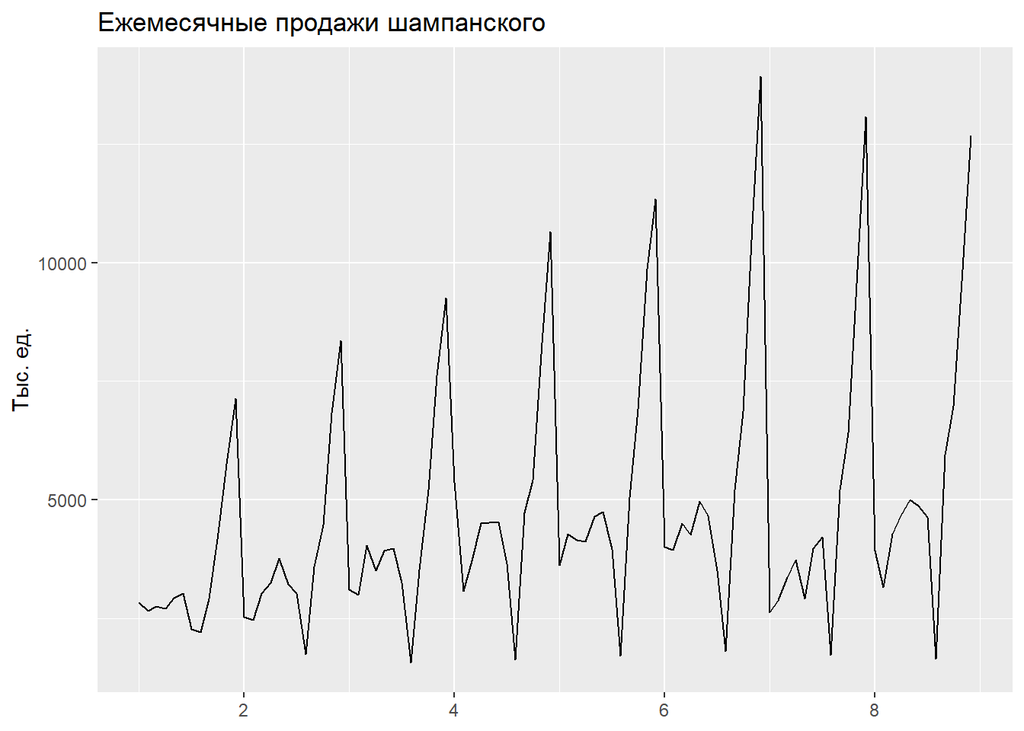

```r
champ_title <- 'Ежемесячные продажи шампанского'
champ_unit <- 'Тыс. ед.'
autoplot(champ) +
  labs(title = champ_title, y = champ_unit, x = NULL) #в виде графика
```

При необходимости, можно извлечь эти компоненты с помощью функций `coredata()` и `index()` соответственно. Частоту ряда можно получить с помощью функции `frequency()`.

Такое может потребоваться, например, для преобразования временного ряда `ts` в обычную таблицу `tibble`.

```r
index(champ) %>% head() # Индекс
```

```
## [1] 1.00 1.08 1.17 1.25 1.33 1.42
```

```r
coredata(champ) %>% head() # Наблюдения
```

```
## [1] 2851 2672 2755 2721 2946 3036
```

```r
frequency(champ) # Частота ряда
```

```
## [1] 12
```

```r
(index(champ) * frequency(champ)) %% frequency(champ) + 1 # Номер месяца по индексу
```

```
##  [1]  1  2  3  4  5  6  7  8  9 10 11 12  1  2  3  4  5  6  7  8  9 10 11
## [24] 12  1  2  3  4  5  6  7  8  9 10 11 12  1  2  3  4  5  6  7  8  9 10
## [47] 11 12  1  2  3  4  5  6  7  8  9 10 11 12  1  2  3  4  5  6  7  8  9
## [70] 10 11 12  1  2  3  4  5  6  7  8  9 10 11 12  1  2  3  4  5  6  7  8
## [93]  9 10 11 12
```

# Как сохранить прогноз в файл

Получим прогноз на 24 месяца по модели Винтерса:

```r
champ_fc <- hw(champ, h = 24)$mean
champ_fc
```

```
##      Jan   Feb   Mar   Apr   May   Jun   Jul   Aug   Sep   Oct   Nov   Dec
## 9   3947  3531  4416  4729  4819  4957  4714  2027  5990  7136 10238 13131
## 10  4186  3769  4655  4968  5058  5196  4953  2266  6229  7375 10477 13370
```

```r
class(champ_fc)
```

```
## [1] "ts"
```

## Сохранение в двоичном формате RDS

Полученный объект также имеет тип `ts`. Такие данные (как и любой объект R) можно сохранить в двоичном формате `RDS` при помощи функции `saveRDS()`:

```r
# Сохранение в файл
champ_fc %>% saveRDS(file = 'data/champ_fc.RDS')
# Считывание из файла
champ_fc2 <- readRDS('data/champ_fc.RDS')
```

Файлы RDS удобны для последующей обработки данных в R, поскольку они очень быстро считываются. Однако если предполагается использовать данные в других программах, потребуется сохранить данные в текстовый файл. Этот формат удобно использовать для обмена между программами.

## Сохранение в текстовый файл - через `zoo`

Наиболее простой способ сохранить данные в текстовый файл - через функцию `zoo::write.zoo()`.

Эта функция автоматически преобразует временной ряд `ts` в формат `zoo`, который используется в одноименном пакете.

```r
champ_fc %>% write.zoo(file = 'data/champ_fc.csv', col.names = c('index', 'forecast'))
```

К недостаткам этого подхода можно отнести неудобный формат индекса. Это не даты, а годы + доли года, соответствующие каждому периоду.

Для максимальной гибкости, можно преобразовать данные в таблицу и в дальнейшем работать с ней.

## Сохранение в текстовый файл - через таблицу

В таблице необходимо отразить дату, соответствующую началу периода, а также само значение прогноза на период. С самим прогнозом проблем нет, а вот дату потребуется сформировать на основе индекса. Для ежемесячных данных удобно использовать функцию `lubridate::make_date()`, которая собирает дату из трех компонентов - год, месяц и день. Номер года можно получить, округлив индекс (он имеет вид: 2017.5) в меньшую сторону. Номер месяца - взяв дробную часть года.

```r
# Функция для преобразования индекса в номер периода в сезонном цикле
i2p <- function(x) {
  (index(x) * frequency(x)) %% frequency(x) + 1 # Номер периода по индексу
}

# Функция для преобразования индекса в дату (только для ежемесячных рядов)
i2month <- function(x) {
  make_date(year = floor(index(x)),
            month = i2p(x))
}

# Создаем таблицу
champ_fc_tbl <-
  tibble(period = i2month(champ_fc),
         forecast = round(coredata(champ_fc)))

# Что получилось
champ_fc_tbl %>% head()
```

```
## # A tibble: 6 x 2
##   period     forecast
##   <date>        <dbl>
## 1 0009-01-01     3947
## 2 0009-02-01     3531
## 3 0009-03-01     4416
## 4 0009-04-01     4729
## 5 0009-05-01     4819
## 6 0009-06-01     4957
```

Для визуализации табличных данных можно использовать все возможности `ggplot2`.

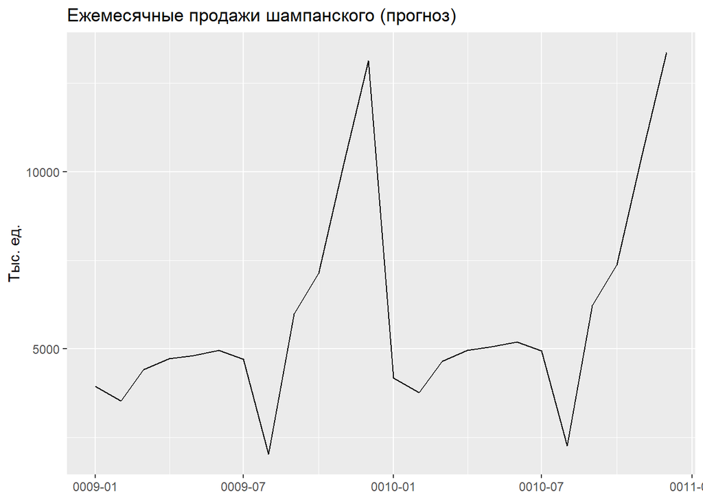

```r
champ_fc_tbl %>%
  ggplot(aes(period, forecast)) +
  geom_line() +
  labs(title = paste(champ_title, '(прогноз)'),
       x = NULL, y = champ_unit)
```

Сохранить данные в файл можно, например, при помощи функции `write.csv2()`:

```r
champ_fc_tbl %>% write.csv2(file = 'data/champ_fc_tbl.csv', row.names = FALSE)
```

# Как получить временной ряд из транзакционных данных

Пакет `forecast` работает только с регулярными временными рядами, в которых наблюдения идут через одинаковые интервалы времени. В то же время, в компаниях данные накапливаются в виде транзакций (заказов, отгрузок и т.п.). Чтобы получить из них временной ряд, необходимо агрегировать данные.

В качестве примера рассмотрим данные о продажах строительных материалов (по дням/отдельным товарам).

```r
sales <- read_csv2(file = 'data/materials.csv')
head(sales)
```

```
## # A tibble: 6 x 5
##   Дата     Товар                                 Группа  Выручка Количество
##   <chr>    <chr>                                 <chr>     <dbl>      <dbl>
## 1 05.07.2~ Грунтовка алкидная ГФ-021 ТЕКС Униве~ Грунто~ 112717.        838
## 2 05.07.2~ Грунтовка вд ОПТИМИСТ для нар/ внутр~ Грунто~  49705.        394
## 3 12.07.2~ Грунтовка алкидная ГФ-021 ТЕКС Униве~ Грунто~ 117460.        936
## 4 12.07.2~ Грунтовка вд ОПТИМИСТ для нар/ внутр~ Грунто~  12417.        106
## 5 19.07.2~ Грунтовка алкидная ГФ-021 ТЕКС Униве~ Грунто~   4080          32
## 6 19.07.2~ Грунтовка вд ОПТИМИСТ глубокого прон~ Грунто~   1108.         15
```

В качестве примера возьмем наиболее ходовой товар в категории `Грунтовка`:

```r
sales %>% filter(`Группа` == 'Грунтовка') %>% group_by(`Товар`) %>%
  summarise(`Количество` = sum(`Количество`)) %>% arrange(desc(`Количество`))
```

```
## # A tibble: 17 x 2
##    Товар                                                         Количество
##    <chr>                                                              <dbl>
##  1 Грунтовка алкидная ГФ-021 ТЕКС Универсал красно-коричневая, ~    3104398
##  2 Грунтовка вд полимерная ESКARO AQUASTOP Prof 3 л, шт             1469532
##  3 Грунтовка вд полимерная ESКARO AQUASTOP, 1 л, шт                 1217616
##  4 Грунтовка вд полимерная ESКARO AQUASTOP Prof 10 л, шт             638332
##  5 Грунтовка вд полимерная ESКARO AQUASTOP, 3 л, шт                  571469
##  6 Грунтовка вд полимерная ESCARO AQUASTOP, 10 л, шт                 449951
##  7 Грунтовка BECKERS Metallprimer GRA серая, 1 л, шт                 251821
##  8 Грунтовка вд BECKERS Skotte Grund Vit 10 л, шт                    215187
##  9 Грунтовка BECKERS Metallprimer GRA серая, 3 л, шт                 180048
## 10 Грунтовка ALPINA Grunt-Konzentrat, 1 л, шт                        142515
## 11 Грунтовка вд ОПТИМИСТ БЕТО-КОНТАКТ сцепляющая, 3 кг, шт           134271
## 12 Грунтовка полимерная КРЕПС Праймер, 10 кг, шт                      84402
## 13 Грунтовка вд BECKERS Skotte Grund Vit 4 л, шт                      83051
## 14 Грунтовка вд ОПТИМИСТ укрывающая, для нар/внутр. работ, 7л, ~      49198
## 15 Грунтовка вд ОПТИМИСТ для нар/ внутр. работ, желтая этикетка~      17245
## 16 Грунтовка алкидная ГФ-021 ТЕКС Универсал красно-коричневая, ~       5627
## 17 Грунтовка вд ОПТИМИСТ глубокого проникновения, зеленая этике~        465
```

Таким товаром оказалась грунтовка ГФ-021 (`Грунтовка алкидная ГФ-021 ТЕКС Универсал красно-коричневая, 2.5 кг, шт`)

Отберем данные только по одному товару и сгруппируем продажи по месяцам. Для выделения месяца, воспользуемся функцией `lubridate::floor_date()`, которая округляет даты с заданной точностью:

```r
sales_monthly_tbl <- sales %>%
  filter(`Товар` == 'Грунтовка алкидная ГФ-021 ТЕКС Универсал красно-коричневая, 2.5 кг, шт' ) %>%
  mutate(`Месяц` = floor_date(dmy(`Дата`), unit = 'month')) %>%
  group_by(`Месяц`) %>%
  summarise(`Количество` = sum(`Количество`)) %>%
  arrange(`Месяц`)

head(sales_monthly_tbl)
```

```
## # A tibble: 6 x 2
##   Месяц      Количество
##   <date>          <dbl>
## 1 2004-10-01       4639
## 2 2004-11-01      28376
## 3 2004-12-01      10316
## 4 2005-01-01      58205
## 5 2005-02-01      69608
## 6 2005-03-01      88843
```

Визуализация ряда:

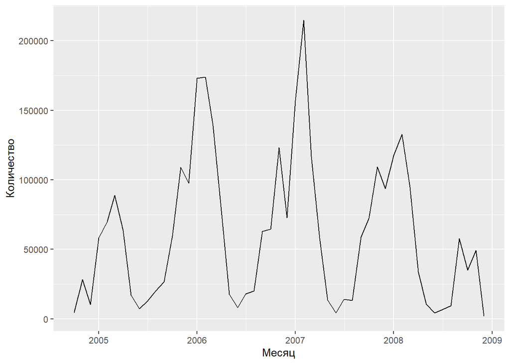

```r
sales_monthly_tbl %>%
  ggplot(aes(`Месяц`, `Количество`)) +
    geom_line()
```

В данном случае ряд продаж не содержит пропусков. Однако часто товар не продается в течение нескольких периодов (например, из-за out-of-stock). В этом случае периоды без продаж не будут присутствовать в данных, и их нужно обязательно восстановить (заполнить нулями или “восстановленными” значениями). Эту задачу можно решить, создав таблицу, в которой будут присутствовать все периоды и “подтянуть” туда фактические данные.

```r
# Все месяцы в диапазоне
all_dates <- seq(from = min(sales_monthly_tbl$`Месяц`),
                 to = max(sales_monthly_tbl$`Месяц`),
                 by = '1 month')

# Делаем таблицу, добавляем известные данные (левое соединение)
all_dates_tbl <- tibble(`Месяц` = all_dates) %>%
  left_join(sales_monthly_tbl, by = 'Месяц')

# Если были пропуски - заполняем нулями
all_dates_tbl_fixed <- all_dates_tbl %>%
  mutate(`Количество` = coalesce(`Количество`, 0))
```

Если бы в данных были пропуски, то после слияния таблиц им бы соответствовали пустые значения, которые можно заменить на 0 при помощи функции `dplyr::coalesce()`.

Теперь можно сделать из данных временной ряд `ts` и сделать прогноз.

```r
# Начало ряда
first_year <- all_dates_tbl_fixed$Месяц %>% year() %>% first()
first_month <- all_dates_tbl_fixed$Месяц %>% month() %>% first()

# Создаем временной ряд
grunt_ts <- ts(all_dates_tbl_fixed$Количество,
               start = c(first_year, first_month),
               frequency = 12)

# Что получилось
grunt_ts
```

```
##         Jan    Feb    Mar    Apr    May    Jun    Jul    Aug    Sep    Oct
## 2004                                                                  4639
## 2005  58205  69608  88843  63830  17016   7159  12609  20170  26508  59688
## 2006 173042 174044 139093  77569  17740   8086  17774  20208  62884  64624
## 2007 157053 214782 116955  58070  13518   4383  13981  13287  58720  72457
## 2008 117561 132718  94737  33829  10422   4252   6829   9366  57751  35152
##         Nov    Dec
## 2004  28376  10316
## 2005 109019  97526
## 2006 123255  72624
## 2007 109332  93810
## 2008  49267   1711
```

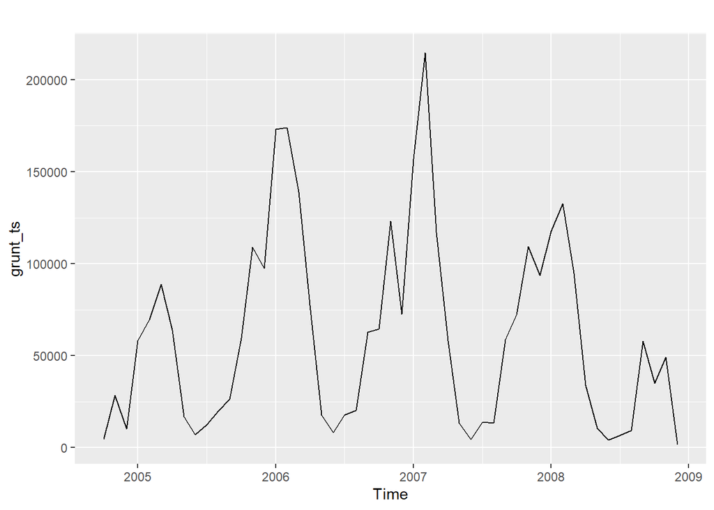

```r
autoplot(grunt_ts)
```

Прогноз

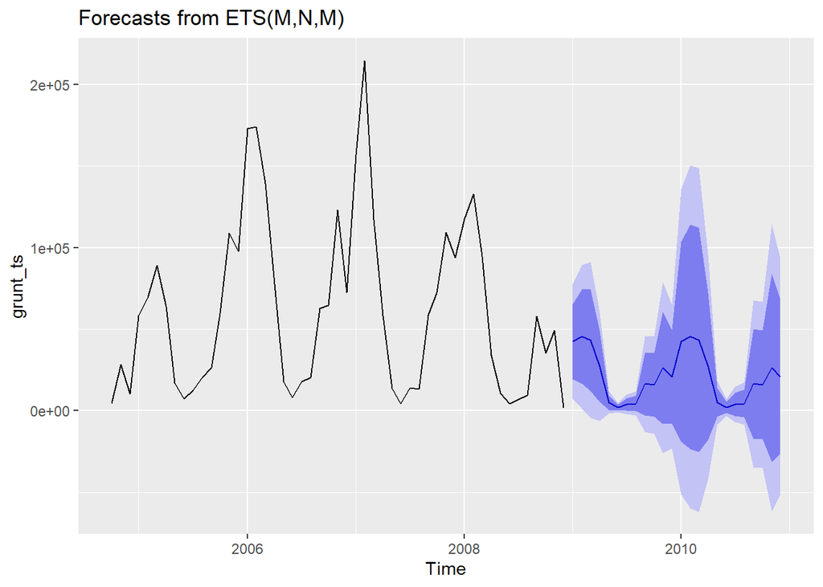

```r
# Прогноз
grunt_m <- ets(grunt_ts, model = 'ZNM')
grunt_fc <- forecast(grunt_m, h = 24)

autoplot(grunt_fc)
```

# Временные ряды и tidyverse

R непрерывно развивается и участники сообщества постоянно создают новые пакеты. Так, в 2017 году в CRAN были добавлены пакеты, позволяющие работать с временными рядами, используя табличный формат данных.

С ними можно познакомиться здесь:

- `timetk` - для преобразования временных рядов в таблицы и обратно - https://business-science.github.io/timetk/
- `sweep` - для преобразования моделей временных рядов и прогнозов по ним в таблицы - https://business-science.github.io/sweep/
- `tidyquant` - для работы с финансовыми временными рядами - https://business-science.github.io/tidyquant/